# Assignment 6A

Brian Roepke

October 18, 2020

## Assignment 6A: Google Studio HOA & R Programming

```r
library(dplyr, warn.conflicts = FALSE)
library(readxl)
library(tidyr, warn.conflicts = FALSE)
library(tidyverse, warn.conflicts = FALSE)
library(ggrepel)
```

```r
df <- read_excel('SocialMediaRevenue.xlsx', 'Dataset1')
```

```r
df <- df %>%
  rename(social_media = 'Social Network') %>%
  rename_all(tolower) %>%
  drop_na()
```

### 2) Data Translations

```r
df <- df %>%
  mutate(session_share = sessions / sum(sessions)) %>%
  mutate(sales_share = transactions / sum(transactions)) %>%
  mutate(revenue_share = revenue / sum(revenue))

names(df)[names(df) == "transactions"] <- "sales"
df <- df[order(-df$session_share),]
```

### 3) Structure, contents and summary of the transformed data frame.

```r
str(df)
```

```
## tibble [14 × 8] (S3: tbl_df/tbl/data.frame)
##  $ social_media : chr [1:14] "YouTube" "Twitter" "Facebook" "Google Groups" ...
##  $ sales        : num [1:14] 2 2 2 1 0 0 0 0 0 0 ...
##  $ users        : num [1:14] 19679 3244 2345 1070 644 ...
##  $ revenue      : num [1:14] 91.2 56.5 217 74.4 0 0 0 0 0 0 ...
##  $ sessions     : num [1:14] 21028 3614 2702 1255 668 ...
##  $ session_share: num [1:14] 0.6811 0.1171 0.0875 0.0407 0.0216 ...
##  $ sales_share  : num [1:14] 0.286 0.286 0.286 0.143 0 ...
##  $ revenue_share: num [1:14] 0.208 0.129 0.494 0.169 0 ...
```

```r
df
```

```
## # A tibble: 14 x 8
##    social_media sales users revenue sessions session_share sales_share
##    <chr>        <dbl> <dbl>   <dbl>    <dbl>         <dbl>       <dbl>
##  1 YouTube          2 19679    91.2    21028      0.681          0.286
##  2 Twitter          2  3244    56.5     3614      0.117          0.286
##  3 Facebook         2  2345   217       2702      0.0875         0.286
##  4 Google Grou…     1  1070    74.4     1255      0.0407         0.143
##  5 reddit           0   644     0        668      0.0216         0
##  6 Quora            0   542     0        560      0.0181         0
##  7 wikiHow          0   291     0        318      0.0103         0
##  8 LinkedIn         0   226     0        249      0.00807        0
##  9 Google+          0   177     0        179      0.00580        0
## 10 Pinterest        0    96     0        108      0.00350        0
## 11 VKontakte        0    57     0         75      0.00243        0
## 12 Blogger          0    58     0         74      0.00240        0
## 13 Hacker News      0    31     0         31      0.00100        0
## 14 Pocket           0    10     0         12      0.000389       0
## # … with 1 more variable: revenue_share <dbl>
```

```r
summary(df)
```

```
##  social_media           sales          users            revenue
##  Length:14          Min.   :0.00   Min.   :   10.0   Min.   :  0.00
##  Class :character   1st Qu.:0.00   1st Qu.:   67.5   1st Qu.:  0.00
##  Mode  :character   Median :0.00   Median :  258.5   Median :  0.00
##                     Mean   :0.50   Mean   : 2033.6   Mean   : 31.36
##                     3rd Qu.:0.75   3rd Qu.:  963.5   3rd Qu.: 42.38
##                     Max.   :2.00   Max.   :19679.0   Max.   :217.00
##     sessions        session_share        sales_share      revenue_share
##  Min.   :   12.00   Min.   :0.0003887   Min.   :0.00000   Min.   :0.00000
##  1st Qu.:   83.25   1st Qu.:0.0026965   1st Qu.:0.00000   1st Qu.:0.00000
##  Median :  283.50   Median :0.0091828   Median :0.00000   Median :0.00000
##  Mean   : 2205.21   Mean   :0.0714286   Mean   :0.07143   Mean   :0.07143
##  3rd Qu.: 1108.25   3rd Qu.:0.0358971   3rd Qu.:0.10714   3rd Qu.:0.09650
##  Max.   :21028.00   Max.   :0.6811129   Max.   :0.28571   Max.   :0.49419
```

### Summary Statistics Interpretation

- **sales**: The number of sales transactions per social media channel. The numbers were relatively low, with only a max of `2.0`.
- **users**: Total number of users per social media channel. The largest channel had `19,679` users and the smallest only `10`. This large variance is also displayed by the delta between the mean (`2033.6`) and median (`258.5`) values.
- **revenue**: Total amount of revenue per social media channel. Max of `217` and min of `0`. The mean of `31.36` across all channels gives us a pretty good indication of the sales potential regarding social media channels.
- **sessions**: Total number of sessions per social media channel. with the max of `21028` just larger than the user max of `19679`, most users visit the site only once.
- **session_share**: This column is calculated as the how many sessions each channel makes up of the whole. Descriptive statistics here are less useful considering this. We do see, however, that the largest share was `68.1%`, showing us that one channel was dominant (YouTube)
- **sales_share**: Sales share is also a calculation of the proportion of sales relative to the whole. In this case, the max was `28.6%`, dramatically lower than the session share.
- **revenue_share**: Revenue share is our last calculated column; this shows us that the max value was `49.4%`, telling us that half the revenue was generated from a single channel (Facebook).

### Session Share vs Sales Share by Social Media

This plot shows the relationship between `sessions` vs `sales` (as a percentage of total) for each social media, even those which did not produce any sales.

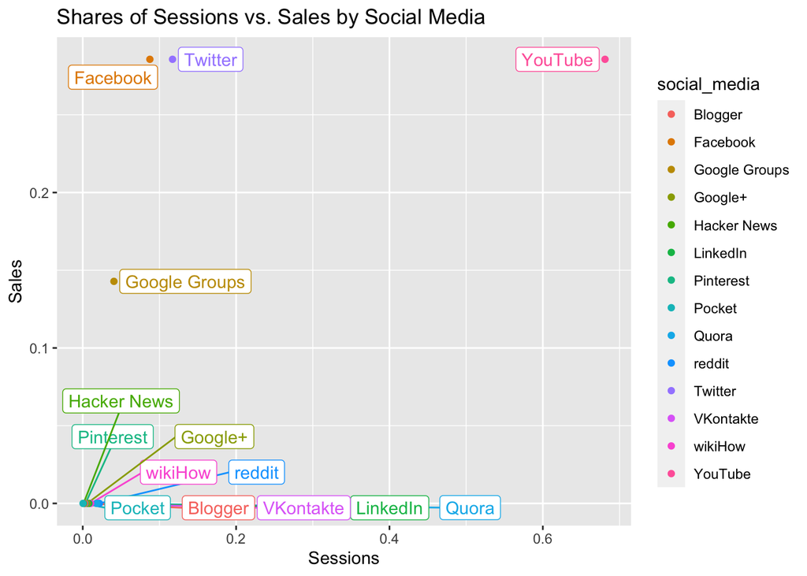

```r
ggplot(df, mapping = aes(x = session_share,
                         y = sales_share,
                         color = social_media,
                         label = social_media)) +
  geom_label_repel(aes(),
                   show.legend = FALSE
             ) +
    ggtitle("Shares of Sessions vs. Sales by Social Media") +
  xlab("Sessions") +
  ylab("Sales") +
  geom_point()
```

A large number of Social Media sites had a negligible contribution to both sales and session proportions. These are all clustered in the lower left of the scatter plot. Four different sites constitute nearly all of the sessions and sales: Google Groups, Facebook, Twitter, and the leader, YouTube.

### 5) Remove all Social Media Sites without Sales

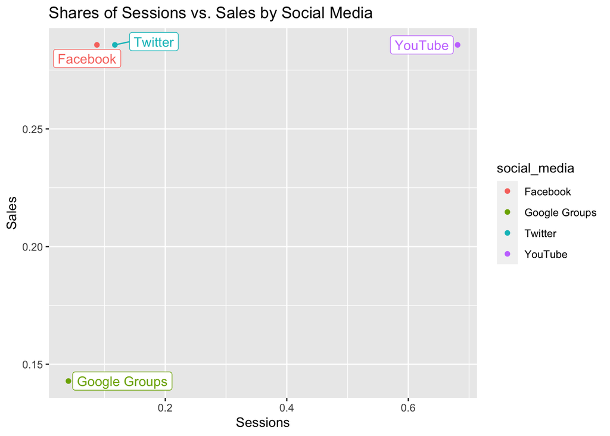

```r
df1 <- filter(df, sales > 0)

ggplot(df1, mapping = aes(x = session_share,
                          y = sales_share,
                          color = social_media,
                          label = social_media)) +
  geom_label_repel(aes(),
                   show.legend = FALSE) +
  ggtitle("Shares of Sessions vs. Sales by Social Media") +
  xlab("Sessions") +
  ylab("Sales") +
  geom_point()
```

The same plot as above but, those with 0 sales removed from the plot regardless of sessions. We see about the same picture as before; however, it shows the contrast in the delta between Google Groups and the other three; Facebook, Twitter, and YouTube.

### 6) Share of Revenue vs. Share of Sessions

Next looking at Revenue ($) contribution as opposed to sales transactions.

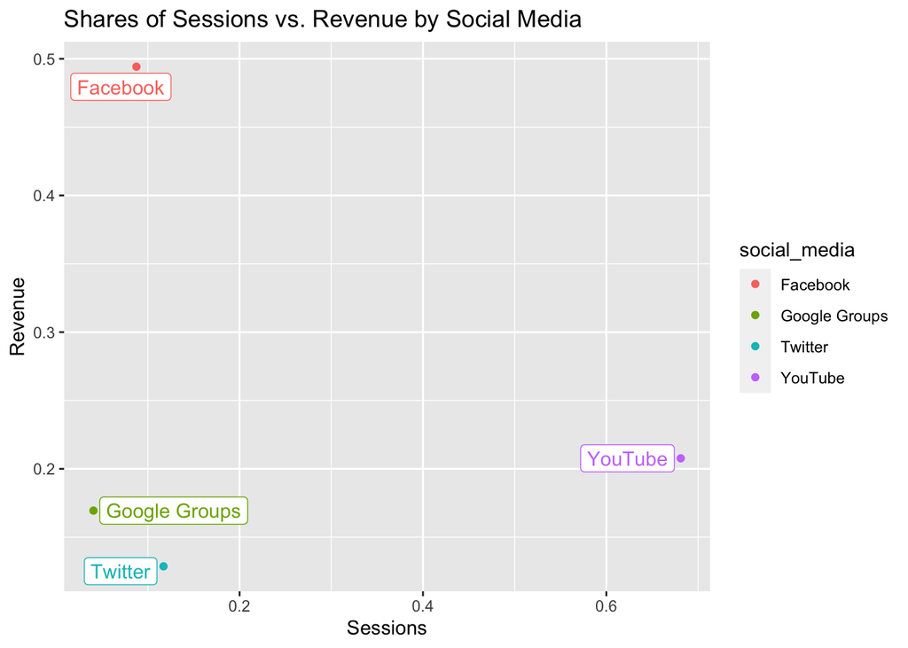

```r
ggplot(df1, mapping = aes(x = session_share,
                         y = revenue_share,
                         color = social_media,
                         label = social_media)) +
  geom_label_repel(aes(),
                   show.legend = FALSE
             ) +
  ggtitle("Shares of Sessions vs. Revenue by Social Media") +
  xlab("Sessions") +
  ylab("Revenue") +
  geom_point()
```

As an alternate of the above Scatter Plot, mapping `Revenue` vs. `Sessions`; you see a different performance view. Facebook is the clear leader in revenue, and while YouTube drove a significantly higher share of sessions, it doesn’t produce the revenue commiserate with those sessions.

## Conversion Rate of Sales by Users

Calculate how each social media site performs regarding conversion rate.

```r
df2 <- df %>%
  mutate(user_convrate_perc = (sales / users)) %>%
  filter(sales > 0)
```

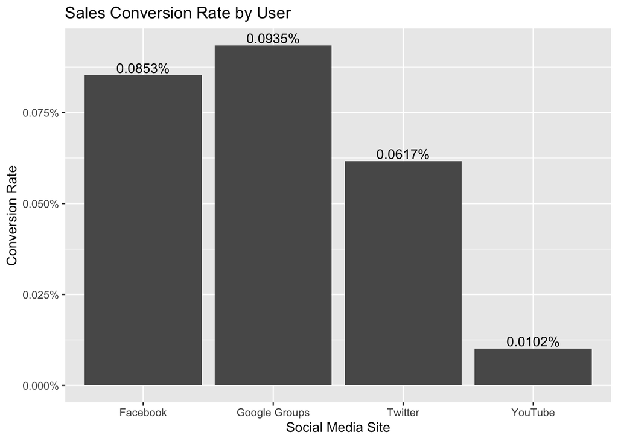

```r
ggplot(df2, aes(social_media, user_convrate_perc)) +
  ggtitle("Sales Conversion Rate by User") +
  xlab("Social Media Site") +
  ylab("Conversion Rate") +
  geom_text(aes(label=scales::percent(user_convrate_perc),
                vjust=-0.25)) +
  scale_y_continuous(labels = scales::percent) +
  geom_col()
```

Based on the conversion rate, Google groups actually performed the best with Facebook second. Facebook being the best overall performer in revenue (as show previously) as well.

## User Distribution

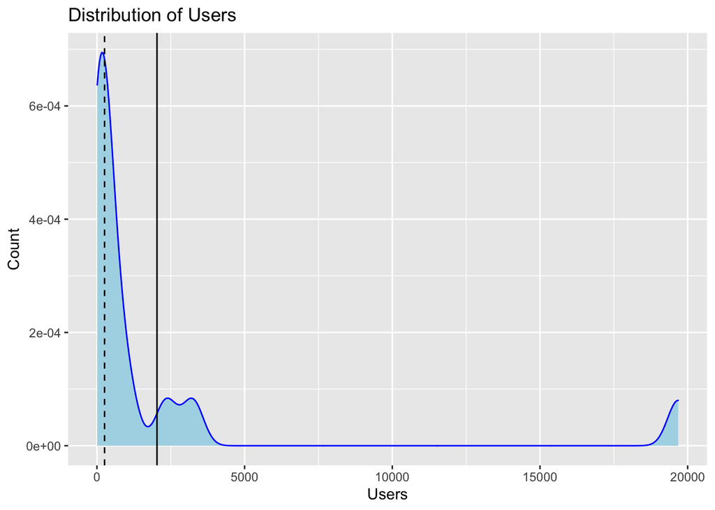

```r
df %>%
    ggplot(aes(users)) +
    geom_density(color = "blue",fill = "lightblue") +
    geom_vline(xintercept = mean(df$users), lwd = 0.5) +
    geom_vline(xintercept = median(df$users), lwd = 0.5, linetype = 'dashed') +
    labs(title = "Distribution of Users",
         x = "Users",
         y = "Count")
```

```r
library(moments)
skewness(df$users)
```

```
## [1] 3.138767
```

A skewness of `0` would equal a normla distribution, a skewness of `3.1` shows that the data is extremely right skewed.

## Plotting Users vs. Sessions

Next, exploring the correlation of Users and Sessions and building a prediction model.

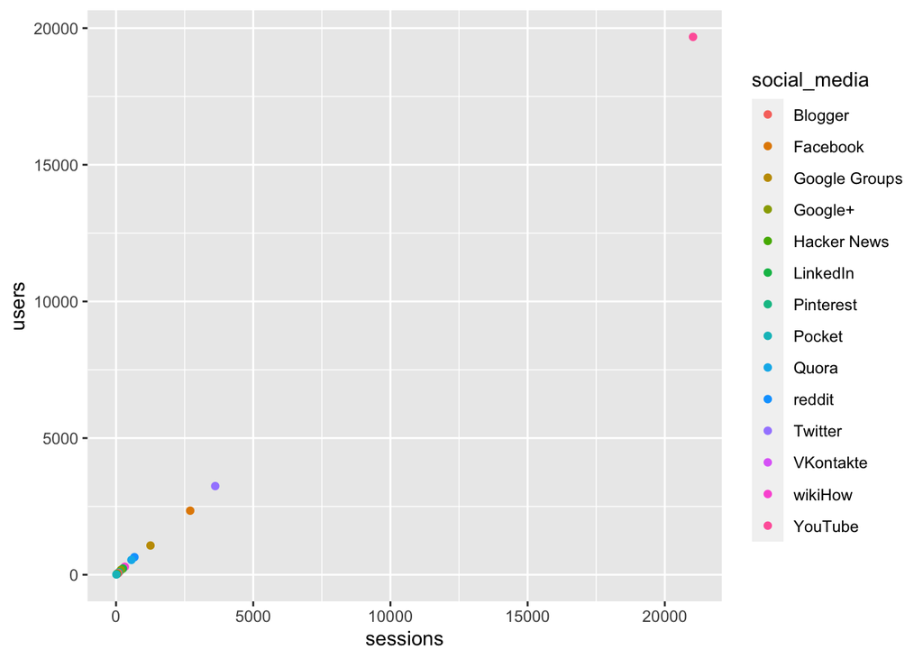

```r
ggplot(df, mapping = aes(x = sessions,
                         y = users,
                         color = social_media,
                         label = social_media)) +
  geom_point()
```

Because we can see a positive correlation displayed by the linear relationship of the points, we’ll run a quick linear regression model to see how close this relationship is.

```r
model <- lm(users ~ sessions, data = df)

summary(model)
```

```
##
## Call:
## lm(formula = users ~ sessions, data = df)
##
## Residuals:
##     Min      1Q  Median      3Q     Max
## -153.27   16.52   23.45   36.72   48.34
##
## Coefficients:
##               Estimate Std. Error t value Pr(>|t|)
## (Intercept) -29.189654  19.060780  -1.531    0.152
## sessions      0.935402   0.003307 282.855   <2e-16 ***
## ---
## Signif. codes:  0 '***' 0.001 '**' 0.01 '*' 0.05 '.' 0.1 ' ' 1
##
## Residual standard error: 65.89 on 12 degrees of freedom
## Multiple R-squared:  0.9999, Adjusted R-squared:  0.9998
## F-statistic: 8.001e+04 on 1 and 12 DF,  p-value: < 2.2e-16
```

The R-squared value of `0.9999` tells us that `99.99%` of all variance in the fixed, variable Users relationship is explained by the number of sessions on the site. This model allows us to build a reliable prediction model for how many users there are on a site based on the session per social media source.